# wuebker_assignment1

## MFE Spring 2021

## Assignment 1

Student Name: Rick Wuebker

ID: richard_wuebker

Solved in team: No

# 1. Bond Pricing

> **a. Derive a formula for the value of a growing perpetuity with growth rate g and discount rate r where:**

$$ 0 < g < r $$$$ B = \sum\limits_{k=0}^\infty \frac{C(1+g)^k}{(1+r)^{k+1}} $$

$$ B = C\sum\limits_{k=0}^\infty \frac{(1+g)^k}{(1+r)^{k+1}} $$

$$ B = \frac{C}{(1+r)}\sum\limits_{k=0}^\infty \Big(\frac{1+g}{1+r}\Big)^k $$

$$ 0 < g < r \implies \Big(\frac{1+g}{1+r}\Big) < 1 $$

$$ B = \frac{C}{(1+r)} \Bigg(\frac{1}{1 - \frac{1+g}{1+r}}\Bigg) \;\;\; \because\;\;\;\sum\limits_{k=0}^\infty x^k = \frac{1}{1-x}$$

$$ B = \frac{C}{(1+r)} \Bigg(\frac{1 + r}{r - g}\Bigg) $$

$$ B = \frac{C}{r - g} $$

> **b. As of December 31, 2014, calculate the value of the comet perpetuity. First payment at end of 2061 and occurs every 76 years, the value being the year, $ r = 1\% $**

$$ B = \sum\limits_{k=0}^\infty \frac{2061 + 76k}{(1.01)^{47 + 76k}}$$

$$ B = \frac{1}{1.01^{47}}\sum\limits_{k=0}^\infty \frac{2061 + 76k}{1.01^{76k}}$$

$$ B = \frac{1}{1.01^{47}}\Bigg(\sum\limits_{k=0}^\infty \frac{2061}{1.01^{76k}} + \sum\limits_{k=0}^\infty \frac{76k}{1.01^{76k}} \Bigg) \tag{1} $$

I will solve each of the sums in parens individually

$$ *** $$

$$ \sum\limits_{k=0}^\infty \frac{2016}{1.01^{76k}} = 2061\sum\limits_{k=0}^\infty \bigg(\frac{1}{1.01^{76}}\bigg)^k = 2061\Bigg(\frac{1}{1 - \frac{1}{1.01^{76}}}\Bigg) = 2061\Bigg(\frac{1.01^{76}}{1.01^{76} - 1}\Bigg) \approx 3884.5392$$

$$ *** $$

$$ \textrm{Let } V = \sum\limits_{k=0}^\infty \frac{76k}{1.01^{76k}}$$

$$V = \sum\limits_{k=0}^\infty \frac{76k}{1.01^{76k}} = \sum\limits_{k=1}^\infty \frac{76(k-1)}{1.01^{76(k-1)}} = \sum\limits_{k=1}^\infty \frac{76(k-1)}{1.01^{(76k-76)}} = (1.01^{76})\sum\limits_{k=1}^\infty \Big(\frac{76(k-1)}{1.01^{76k}}\Big) $$

$$ V= (1.01^{76})\Bigg(\sum\limits_{k=1}^\infty \frac{76k}{1.01^{(76k)}} - \sum\limits_{k=1}^\infty \frac{76}{1.01^{(76k)}} \Bigg)$$

$$ V= (1.01^{76})\Bigg(V - \sum\limits_{k=1}^\infty \frac{76}{1.01^{(76k)}} \Bigg) \;\;\;\; \because \;\;\;\; \sum\limits_{k=0}^\infty \frac{76k}{1.01^{76k}} = \sum\limits_{k=1}^\infty \frac{76k}{1.01^{76k}}$$

$$ V= (1.01^{76})V - 76(1.01^{76})\sum\limits_{k=1}^\infty \frac{1}{1.01^{(76k)}}$$

$$ V - (1.01^{76})V = -76(1.01^{76})\sum\limits_{k=1}^\infty \frac{1}{1.01^{(76k)}}$$

$$ V[1 - (1.01^{76})] = -76\sum\limits_{k=1}^\infty \frac{1}{1.01^{76k-76}} $$

$$ V[1 - (1.01^{76})] = -76\sum\limits_{k=1}^\infty \frac{1}{1.01^{76(k-1)}} $$

$$ V[1 - (1.01^{76})] = -76\sum\limits_{k=0}^\infty \Big(\frac{1}{1.01^{76}}\Big)^k $$

$$ V[1 - (1.01^{76})] = -76\Bigg(\frac{1}{1 - \frac{1}{1.01^{76}}}\Bigg) $$

$$ V[1 - (1.01^{76})] = -76\Bigg(\frac{1.01^{76}}{1.01^{76} - 1}\Bigg) $$

$$ V = 126.7396 $$

Plugging the two sums back into (1)

$$ B \approx \frac{1}{1.01^{47}} (3884.5392 + 126.7396) $$

$$ B \approx 2512.9178 $$

# 2. Portfolio Hedging

> **a. Derive the delta of a vanilla european put option from the formula:**

$$ P_k(S) = Ke^{-rT}[1 - N(x-\sigma\sqrt{T})] - S[1 - N(x)] $$$$ x = \frac{ln(S/K) + (r + \sigma^2/2)T}{\sigma\sqrt{T}} $$$$ N'(x) = \frac{1}{\sqrt{2\pi}}e^{-\frac{x^2}{2}} $$

$$ *** Solution *** $$

$$ \Delta x_S = \frac{1}{S\sigma\sqrt{T}} $$

$$ \Delta P = -Ke^{-rT}N'(x - \sigma\sqrt{T}) \Delta x_S - 1 + N(x) + SN'(x)\Delta x_S$$

$$ \Delta P = -Ke^{-rT}\frac{1}{\sqrt{2\pi}}e^{-\frac{(x-\sigma\sqrt{T})^2}{2}} \Delta x_S - 1 + N(x) + SN'(x)\Delta x_S \;\;\; \because \;\;\; N'(x-\sigma\sqrt{T}) = \frac{1}{\sqrt{2\pi}}e^{-\frac{(x-\sigma\sqrt{T})^2}{2}}$$

$$ \Delta P = -Ke^{-rT}\frac{1}{\sqrt{2\pi}}e^{-\frac{(x^2 - 2x\sigma\sqrt{T} + \sigma^2T)}{2}} \Delta x_S - 1 + N(x) + SN'(x)\Delta x_S $$

$$ \Delta P = \frac{-Ke^{-rT}e^{-\frac{x^2}{2}}e^{-\frac{\sigma^2T}{2}} e^{x\sigma\sqrt{T}}}{\sqrt{2\pi}} \Delta x_S + \frac{Se^{-\frac{x^2}{2}}}{\sqrt{2\pi}}\Delta x_S +N(x) - 1$$

$$ \Delta P = \frac{\Delta x_S e^{-\frac{x^2}{2}}}{\sqrt{2\pi}} \Big(S - Ke^{-rT}e^{-\frac{\sigma^2T}{2}}e^{x\sigma\sqrt{T}} \Big) + N(x)-1$$

$$ \Delta P = \frac{\Delta x_S e^{-\frac{x^2}{2}}}{\sqrt{2\pi}} \Big(S - Ke^{-rT}e^{-\frac{\sigma^2T}{2}}e^{ln(S) - ln(k) +(r + \sigma^2/2)T } \Big) + N(x)-1$$

$$ \Delta P = \frac{\Delta x_S e^{-\frac{x^2}{2}}}{\sqrt{2\pi}} \Big(S - Ke^{-rT}e^{-\frac{\sigma^2T}{2}}\frac{S}{K}e^{rT}e^{\frac{\sigma^2T}{2} } \Big) + N(x)-1$$

$$ \Delta P = \frac{\Delta x_S e^{-\frac{x^2}{2}}}{\sqrt{2\pi}} \Big(S - S\Big) + N(x)-1$$

$$ \Delta P = N(x)-1$$

> **b. Derive the formula for the gamma of a put option**

$$ \Gamma_P = \frac{\partial(N(x) - 1)}{\partial S} $$

$$ \Gamma_P = N'(x)\Delta x_S \;\;\; \textrm{where} \;\;\; \Delta x_S = \frac{\partial \Bigg(\frac{ln(S/K) + (r + \sigma^2/2)T}{\sigma\sqrt{T}}\Bigg)}{\partial(S)} = \frac{\partial \Bigg(\frac{ln(S) - ln(K) + (r + \sigma^2/2)T}{\sigma\sqrt{T}}\Bigg)}{\partial(S)} = \frac{1}{S\sigma\sqrt{T}}$$

$$ \Gamma_P = \frac{N'(x)}{S\sigma\sqrt{T}} $$

> **c. Use Taylor's formula to derive expressions for $h_1$ and $h_2$ in the delta-gamma neutral hedge as a function of $\Delta_{P_{K_1}}$, $\Delta_{P_{K_2}}$, $\Gamma_{P_{K_1}}$ and $ \Gamma_{P_{K_2}} $**

$$ V(S) = h_S S + h_1P_1(S) + h_2P_2(S) $$

$$ V(S + \Delta S) = V(S) + \Delta S\frac{\partial{V(S)}}{\partial S} + \frac{(\Delta S)^2}{2} \frac{\partial^2 V(S)}{\partial S^2} + \mathcal{O}(\Delta S)^3 $$

$$ V(S + \Delta S) = V(S) + \Delta S (h_S + h_1 \Delta_{P_1} + h_2 \Delta_{P_2}) + \frac{(\Delta S)^2}{2}(h_1 \Gamma_{P_1} + h_2\Gamma_{P_2}) + \mathcal{O}(\Delta S)^3 $$

$$ V(S + \Delta S) - V(S) = \Delta S (h_S + h_1 \Delta_{P_1} + h_2 \Delta_{P_2}) + \frac{(\Delta S)^2}{2}(h_1 \Gamma_{P_1} + h_2\Gamma_{P_2}) + \mathcal{O}(\Delta S)^3 $$

We want to set the change in portfolio value to zero

$$ \Delta S (h_S + h_1 \Delta_{P_1} + h_2 \Delta_{P_2}) + \frac{(\Delta S)^2}{2}(h_1 \Gamma_{P_1} + h_2\Gamma_{P_2}) =0 $$

I will split these up to set the first order effect to zero and set the second order effect to zero to solve the system for $h_1$ and $h_2$

$$ \Delta S (h_S + h_1 \Delta_{P_1} + h_2 \Delta_{P_2}) = 0 \;\;\;\;\;\;\;\;\;\;\;\;\;\;\;\;\;\;\;\;\;\;\;\;\;\;\;\;\;\;\;\;\;\;\;\;\;\;\;\; \frac{(\Delta S)^2}{2}(h_1 \Gamma_{P_1} + h_2\Gamma_{P_2}) =0 $$

$$ h_1 \Delta_{P_1} + h_2 \Delta_{P_2} = -h_S \;\;\;\; (1) \;\;\;\;\;\;\;\;\;\;\;\;\;\;\;\;\;\;\;\;\;\;\;\;\;\;\;\;\;\;\;\;\;\;\;\;\;\;\;\; h_1 \Gamma_{P_1} + h_2\Gamma_{P_2} =0 \;\;\;\;\; (2)$$

I will solve for $h_1$ in (1) then plug it into (2) to solve for $h_2$

$$ h_1 = -\frac{(h_S + h_2 \Delta_{P_2})}{\Delta_{P_1}} \;\;\;\;\;\;\; (3) \;\;\;\;\;\;\;\;\;\;\;\;\;\;\;\;\;\;\;\;\;\;\;\;\;\;\;\;\;\;\;\;\;\;\;\;\;\;\;\; -\frac{(h_S + h_2 \Delta_{P_2})}{\Delta_{P_1}} \Gamma_{P_1} + h_2\Gamma_{P_2} =0 $$

$$ (h_S + h_2 \Delta_{P_2}) \Gamma_{P_1} - \Delta_{P_1}h_2\Gamma_{P_2} =0 $$

$$ h_S\Gamma_{P_1} + h_2 \Delta_{P_2} \Gamma_{P_1} - \Delta_{P_1}h_2\Gamma_{P_2} = 0 $$

$$h_2( \Delta_{P_2} \Gamma_{P_1} - \Delta_{P_1}\Gamma_{P_2}) = -h_S\Gamma_{P_1} $$

$$h_2 = \frac{-h_S\Gamma_{P_1}}{( \Delta_{P_2} \Gamma_{P_1} - \Delta_{P_1}\Gamma_{P_2})} $$

Now plugging $h_2$ back into (3) to solve for $h_1$

$$ h_1 = \frac{-(h_S + \frac{-h_S\Gamma_{P_1}}{( \Delta_{P_2} \Gamma_{P_1} - \Delta_{P_1}\Gamma_{P_2})} \Delta_{P_2})}{\Delta_{P_1}} $$

$$ h_1 = \frac{-(h_S( \Delta_{P_2} \Gamma_{P_1} - \Delta_{P_1}\Gamma_{P_2}) - h_S\Gamma_{P_1} \Delta_{P_2})}{\Delta_{P_1}( \Delta_{P_2} \Gamma_{P_1} - \Delta_{P_1}\Gamma_{P_2})} $$

$$ h_1 = \frac{h_S(\Gamma_{P_1} \Delta_{P_2} - \Delta_{P_2} \Gamma_{P_1} + \Delta_{P_1}\Gamma_{P_2})}{\Delta_{P_1}( \Delta_{P_2} \Gamma_{P_1} - \Delta_{P_1}\Gamma_{P_2})} $$

$$ h_1 = \frac{h_S(\Gamma_{P_1} \Delta_{P_2} - \Delta_{P_2} \Gamma_{P_1} + \Delta_{P_1}\Gamma_{P_2})}{\Delta_{P_1}( \Delta_{P_2} \Gamma_{P_1} - \Delta_{P_1}\Gamma_{P_2})} \;\;\;\;\;\;\;\;\;\;\;\;\;\;\;\;\;\;\;\;\;\;\;\;\;\;\;\;\;\;\;\;\;\;\;\;\;\;\;\; h_2 = \frac{-h_S\Gamma_{P_1}}{( \Delta_{P_2} \Gamma_{P_1} - \Delta_{P_1}\Gamma_{P_2})} $$

# 3. Trading Model

> **a. What is the t = 0 price of the portfolio $h = (1,1,0)^T$**

$$ \overline{D} = \begin{bmatrix} -2 & 1 & 1 \\ -3 & 1 & 2\\ -16 & 8 & 9 \\ \end{bmatrix} $$

$$ p_0 = \begin{bmatrix} 1 & 1 & 0 \end{bmatrix} \begin{bmatrix} -2 \\ -3 \\ -16 \\ \end{bmatrix} = -\$5$$

> **b. Is this market complete?**

> > For completeness we look at the reachable payoff space which is the rowspace of D which is the columnspace of $D^T$

$$ D^T = \begin{bmatrix} 1 & 1 & 8 \\ 1 & 2 & 9 \end{bmatrix} $$

> > We can easily see that column 3 is just 7 times column 1 + column 2, however column 1 and column 2 are linearly independent and span the whole of $R^2$ which is our outcome space, thus the market is complete.

> **c. Does the law of one price (LOOP) hold in this market?**

> > No it does not hold. For example, if we hold 7 shares of asset 1, and 1 share of asset 2, the payoff will be:

$$ \begin{bmatrix} 7 & 1 & 0 \end{bmatrix} \begin{bmatrix} 1 & 1 \\ 1 & 2\\ 8 & 9 \\ \end{bmatrix} = \begin{bmatrix} 8 & 9\end{bmatrix} $$

> > This is the same payoff as holding asset 3. Asset 3 has a cost of 16, but the above portfolio would cost 17 so we have the same outcome but with different prices at time t = 0.

# 4. Law of One Price

> **a. Use your knowledge of linear algebra to prove part 1 of the theorem: The LOOP holds if and only if there exists a state price vector.**

Let $ \mathbf{D} \in \mathbb{R}^{NxM}$ where N = number of securities and M = number of possible outcomes.

Let $\mathbf{s}_0 \in \mathbb{R}^N$ be the initial price vector of assets

Let $\mathbf{h} \in \mathbb{R}^N$ be vector of purchased holdings for each asset.

LOOP holds if $\forall \mathbf{h} : \mathbf{h}^T\mathbf{D} = 0 \implies \mathbf{h}^T\mathbf{s}_0 = 0 \;\;\;\;\;$ **(1)**

We define the state price vector, $\psi \in \mathbb{R}^m$ if $\forall \mathbf{h}: \mathbf{h}^T \mathbf{s}_0 = \mathbf{h}^T D \psi \;\;\;\;\;\;\;$**(2)**

In **(2)** if $\mathbf{h}^T\mathbf{D} = \mathbf{0} \implies \mathbf{h}^T\mathbf{s}_0 = 0$ but this equality holds only where the state price vector exists.

$$\mathbf{h}^T\mathbf{s}_0 = \mathbf{h}^T\mathbf{D}\mathbf{\psi}$$

$$0 = \mathbf{h}^T\mathbf{-s}_0 + \mathbf{h}^T\mathbf{D}\mathbf{\psi}$$

$$ 0 = \mathbf{h}^T [-\mathbf{s}_0 ; \mathbf{D}] \begin{bmatrix} 1 \\ \mathbf{\psi} \end{bmatrix} $$

Let $\mathbf{\overline{D}} = [-\mathbf{s}_0 | \mathbf{D}] \in \mathbb{R}^{NxM+1}$ be the augemented payoff matrix.

$\implies \begin{bmatrix} 1 \\ \psi \end{bmatrix} \in Nullspace\Big(\mathbf{\overline{D}}\Big)$

Result of fundamental theorem of linear algebra: $Nullspace \Big(\overline{\mathbf{D}}\Big) \oplus range\Big(\overline{\mathbf{D}}^T\Big)$ = M + 1

$\implies Nullspace(\mathbf{D})$ exists when $range\big(\mathbf{\overline{D}}^T\big) <= M$

Conversely if $\psi$ doesn't exist then neither does **(2)** and **(1)** doesn't hold

> **b. Use your knowledge of linear algebra to prove part 2 of the theorem: In a market in which LOOP holds, the state price vector is unique if and only if the market is complete.**

Let $\mathbf{\overline{D}} = [-\mathbf{s}_0 | \mathbf{D}] \in \mathbb{R}^{NxM+1}$ be the augemented payoff matrix.

We can alternatively define the state price vector, $\psi$ if $\forall \mathbf{h}: \mathbf{h}^T \mathbf{\overline{D}} \begin{bmatrix} 1 \\ \psi \end{bmatrix} = \mathbf{0}$

$\implies \begin{bmatrix} 1 \\ \psi \end{bmatrix} \in Nullspace\Big(\mathbf{\overline{D}}\Big)$

Markets are complete if $rank(\mathbf{D}) = M$

$\mathbf{s}_0 = \mathbf{D}\psi \implies \mathbf{s}_0$ is a linear combination of the columns of $\mathbf{D} \implies$ rank$\Big(\mathbf{\overline{D}}\Big) = M$

Result of fundamental theorem of linear algebra: $Nullspace \Big(\overline{\mathbf{D}}\Big) \oplus range\Big(\overline{\mathbf{D}}^T\Big)$ = M + 1

$$ \implies Dim(Nullspace \Big({\mathbf{D}}\Big)) = 1 \because rank\Big(\overline{\mathbf{D}}^T\Big) = M $$

$\implies \psi$ is unique and only scalar multiples of $\begin{bmatrix} 1 \\ \psi \end{bmatrix}$ exist

Conversely, if the market is not complete, $\implies$ rank($\mathbf{\overline{D}}) < M \implies \; Dim(Nullspace(\mathbf{\overline{D}})) > 1 \implies \psi$ exists in a plane or higher space with multiple solutions.

# 5. Eigenvalue Decomposition

> Consider the matrix: $$\begin{bmatrix} 3 & 1 \\ 1 & 3 \\ \end{bmatrix} $$

> **a. What are the eigenvectors and eigenvalues?**

$$ det \Bigg(\begin{bmatrix} 3 - \lambda & 1 \\ 1 & 3 - \lambda \end{bmatrix}\Bigg) $$

$$ = (3-\lambda)(3 - \lambda) - 1 $$

$$ = 9 -6\lambda + \lambda^2 - 1 $$

$$ = \lambda^2 - 6\lambda + 8$$

$$ (\lambda - 4)(\lambda - 2)$$

The eigenvalues = {4,2}

For $ \lambda = 4 $

$$ \begin{bmatrix} -1 & 1 \\ 1 & -1 \end{bmatrix} \begin{bmatrix} x_1 \\ x_2 \end{bmatrix} = \begin{bmatrix} 0 \\ 0 \end{bmatrix} $$

$$ -x_1 + x_2 = 0 $$

$$ x_1 - x_2 = 0 $$

Both of these equations are solved when $ x_1 = x_2 $ so I will use $ x_1 = x_2 = 1 $

The corresponding eigenvector for $\lambda = 4$ is $\begin{bmatrix} 1 \\ 1 \end{bmatrix}$

For $ \lambda = 2 $

$$ \begin{bmatrix} 1 & 1 \\ 1 & 1 \end{bmatrix} \begin{bmatrix} x_1 \\ x_2 \end{bmatrix} = \begin{bmatrix} 0 \\ 0 \end{bmatrix} $$

$$ x_1 + x_2 = 0 $$

$$ x_1 + x_2 = 0 $$

Both of these equations are solved when $ x_1 = -x_2 $ so I will use $ x_1 = 1, x_2 = -1 $

The corresponding eigenvector for $\lambda = 2$ is $\begin{bmatrix} 1 \\ -1 \end{bmatrix}$

> **b. What are the matricies Q and $\Lambda$ in the spectral decomposition $ A = Q\Lambda Q^T $?**

The $\Lambda$ matrix has the eigenvalues on the diagonal and zero otherwise:

$$ \Lambda = \begin{bmatrix} 4 & 0 \\ 0 & 2 \end{bmatrix}$$

$Q$ is just the normalized eigenvectors together

$$ Q = \begin{bmatrix} \frac{1}{\sqrt{2}} & \frac{1}{\sqrt{2}} \\ \frac{1}{\sqrt{2}} & \frac{-1}{\sqrt{2}} \end{bmatrix} $$

```python
# check
import numpy as np
A = np.array([[3, 1], [1, 3]])
lam = np.array([[4, 0], [0, 2]])
Q = np.array([[1/np.sqrt(2), 1/np.sqrt(2)],[1/np.sqrt(2), -1/np.sqrt(2)]])
decomp_A = np.dot(Q, lam).dot(Q.T)
np.allclose(A, decomp_A) # tolerance = 1e-08
```

```
True
```

> **c. Is A positive definite?**

Yes. A is symmetric and all the eigenvalues are positive so it is positive definite.

# 5. Principal Component Analysis

> Complete a principal component analysis of the following data, where we decompose $\mathbf{X} = \mathbf{xc}$ where $\mathbf{X} \in \mathbb{R}^{2x15}$ and $\mathbf{x} \in \mathbb{R}^2$ and $ \mathbf{c} \in \mathbb{R}^{15}$

```python
row1 = [-0.066, -0.124, 0.259, 0.289, -0.318, -0.015, -0.060, 0.140,
        0.203, 0.249, -0.229, 0.174, 0.149, -0.343, -0.305]
row2 = [-0.204, -0.079, 0.565, 0.607, -0.425, -0.135, 0.011, 0.411,
        0.350, 0.535, -0.668, 0.128, 0.317, -0.543, -0.870]
X = np.array([row1, row2])
X.shape
```

```
(2, 15)
```

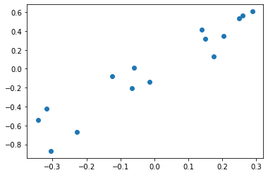

```python
import matplotlib.pyplot as plt
plt.scatter(row1, row2)
```

We want to find the largest eigenvalue associated with the symmetric matrix $X X^T$ and the associated eigenvector will be our **x** vector

$$ A = X X^T $$

```python
A = np.dot(X, X.T)
A
```

```
array([[0.713685, 1.417414],
       [1.417414, 3.126994]])
```

```python
evalues, evectors = np.linalg.eig(A)
evalues
```

```
array([0.05886763, 3.78181137])
```

> **a. What is the optimal x?**

3.7818 is the largest eigenvalue so we will use the associated eigenvector as $\mathbf{x}$

```python
evectors
```

```
array([[-0.9078067 , -0.41938883],
       [ 0.41938883, -0.9078067 ]])
```

```python
x = evectors[:,1].reshape((2,1))
x
```

```
array([[-0.41938883],
       [-0.9078067 ]])
```

$$ \mathbf{x} = \begin{bmatrix} -0.4194 \\ -0.9078 \end{bmatrix} $$

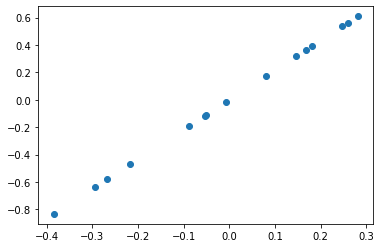

```python
proj_op = x.T.dot(X)
reduced_X = x.dot(proj_op)
plt.scatter(reduced_X[0], reduced_X[1])
```

> **b. What is the error $e = \frac{1}{M}\sqrt{\Sigma_m\left\Vert \mathbf{v}^m - \mathbf{xc}_m \right\Vert_2^2}$**

```python
m = 15
sum_sq_norm_diffs = 0
for i in range(m):
    diff = X[:,i] - reduced_X[:,i]
    norm_diff = np.linalg.norm(diff)
    sq_norm_diff = norm_diff * norm_diff
    sum_sq_norm_diffs += sq_norm_diff

root_sq_norm_diffs = np.sqrt(sum_sq_norm_diffs)
e = root_sq_norm_diffs/m
e
```

```
0.016175101322599528
```

$$ e = 0.0162 $$

> **c. In light of your previous results, is it possible to represent the v's well in a 1-dimensional subspace, $E$?**

The error above appears to be low. Taking a look at both values plotted on the same axes we can see that the reduced line passes through the original points well.

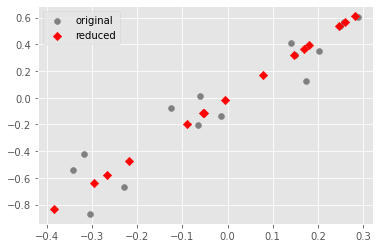

```python
plt.style.use('ggplot')

fig = plt.figure()
ax1 = fig.add_subplot(111)

ax1.scatter(X[0], X[1], c='gray', marker="o", label='original')
ax1.scatter(reduced_X[0], reduced_X[1], c='red', marker="D", label='reduced')
plt.legend(loc='upper left');
plt.show()
```